# FlipTheFleet Black Box Data Tests

Testing Time of Charging

Ben Anderson (b.anderson@soton.ac.uk, `@dataknut`)

Last run at: 2018-10-17 17:40:52

# 1 Citation

If you wish to use any of the material from this report please cite as:

- Anderson, B. (2018) *FlipTheFleet Black Box Data Tests: Testing Time of Charging*, [Centre for Sustainability](http://www.otago.ac.nz/centre-sustainability/), University of Otago: Dunedin, New Zealand.

This work is (c) 2018 the University of Southampton. Re-use is governed by [this license](https://github.com/CfSOtago/GREENGrid/blob/master/LICENSE).

# 2 About

## 2.1 Circulation

Report circulation:

- Restricted to: [NZ GREEN Grid](https://www.otago.ac.nz/centre-sustainability/research/energy/otago050285.html) project partners and contractors.

## 2.2 Purpose

This report is intended to:

- load and test preliminary ‘[black box](https://flipthefleet.org/ev-black-box/)’ (see Figure 2.1) EV monitoring data provided for assessment purposes by [FlipTheFleet](http://flipthefleet.org/)
- preliminary analysis of time of charging to understand impact on ‘peak’ electricity demand

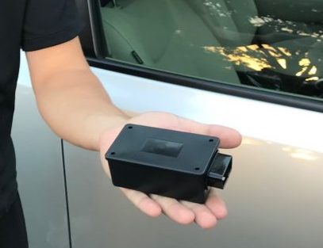

Figure 2.1: The Black Box (Source: FlipTheFleet)

## 2.3 Requirements:

- test FlipTheFleet black box dataset stored on the University of Otago’s High-Capacity Central File Storage [HCS](https://www.otago.ac.nz/its/services/hosting/otago068353.html) at: /Volumes/hum-csafe/Research Projects/GREEN Grid/externalData/flipTheFleet/safe/ftfSafeLatestAll.csv.gz

## 2.4 Code and report history

Generally tracked via our git.soton [repo](https://git.soton.ac.uk/ba1e12/nzGREENGrid):

- [history](https://git.soton.ac.uk/ba1e12/nzGREENGrid/commits/master)
- issues

Specific history of this code:

- https://git.soton.ac.uk/ba1e12/nzGREENGrid/tree/master/analysis/ev

## 2.5 Support

This work was supported by:

- The [University of Otago](https://www.otago.ac.nz/);
- The [University of Southampton](https://www.southampton.ac.uk/);
- The New Zealand [Ministry of Business, Innovation and Employment (MBIE)](http://www.mbie.govt.nz/) through the [NZ GREEN Grid](https://www.otago.ac.nz/centre-sustainability/research/energy/otago050285.html) project;
- [SPATIALEC](http://www.energy.soton.ac.uk/tag/spatialec/) - a [Marie Skłodowska-Curie Global Fellowship](http://ec.europa.eu/research/mariecurieactions/about-msca/actions/if/index_en.htm) based at the University of Otago’s [Centre for Sustainability](http://www.otago.ac.nz/centre-sustainability/staff/otago673896.html) (2017-2019) & the University of Southampton’s Sustainable Energy Research Group (2019-2020).

We do not ‘support’ the code but if you notice a problem please check the issues on our [repo](https://github.com/CfSOtago/GREENGrid) and if it doesn’t already exist, please open a new one.

## 2.6 Notes

This document was created using knitr in [RStudio](http://www.rstudio.com) with R version 3.5.1 (2018-07-02) running on x86_64-apple-darwin15.6.0. Some of the R code has been included where used for information and reference purposes. Full code is [available](https://github.com/CfSOtago/GREENGrid/tree/master/analysis/ev) as noted above.

# 3 Load and check data

## 3.1 Load data

In this section we load and describe the pre-processed safe data from /Volumes/hum-csafe/Research Projects/GREEN Grid/externalData/flipTheFleet/safe/ftfSafeLatestAll.csv.gz. First we load the data.

```r
ftfDT <- data.table::as.data.table(readr::read_csv(dFile))
```

That loaded 46,741 observations.

## 3.2 Create derived variables

Next we create some useful derived variables. Errors may be ‘odd’ dates and times or even not set in the original data as we see below.

```r
t <- ftfDT[is.na(rDate), .(nObs = .N,
                           meanPackVolts = mean(`Pack volts`)),
           keyby = .(`Date (GPS)`, `Time (GPS)`)]

kableExtra::kable(caption = "Number of obs and mean pack volts where date cannot be set by original GPS Date and Time", t) %>% kable_styling()
```

(#tab:check ftf data)Number of obs and mean pack volts where date cannot be set by original GPS Date and Time

| Date (GPS) | Time (GPS) | nObs | meanPackVolts |
| --- | --- | --- | --- |
| NA | NA | 17472 | 90.15239 |

```r
t <- ftfDT[is.na(rTime), .(nObs = .N,
                           meanPackVolts = mean(`Pack volts`)),
           keyby = .(`Date (GPS)`, `Time (GPS)`)]

kableExtra::kable(caption = "Number of obs and mean pack volts where time cannot be set by original GPS Date and Time", t) %>% kable_styling()
```

(#tab:check ftf data)Number of obs and mean pack volts where time cannot be set by original GPS Date and Time

| Date (GPS) | Time (GPS) | nObs | meanPackVolts |
| --- | --- | --- | --- |
| NA | NA | 17472 | 90.15239 |

We remove these NAs from the data

> *XX (should we - what does GPS NA mean? no signal?) XX*

Doing so removed 17472 (37.38 %) observations.

## 3.3 Check variables of interest for this analysis

Check charger related variables. We think these are:

- `Charger (amps)`
- `Charger (V)`

Multiplying these two will give power in W. Figures 3.1 to 3.3 examine the distribution of amps, volts and the derived W.

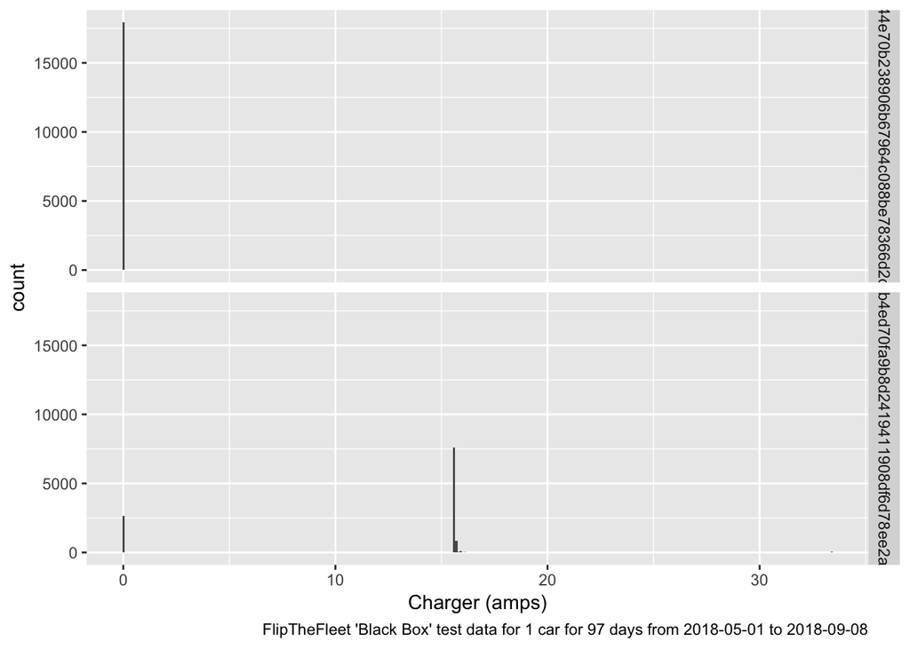

Figure 3.1: Distribution of charger amp readings by car

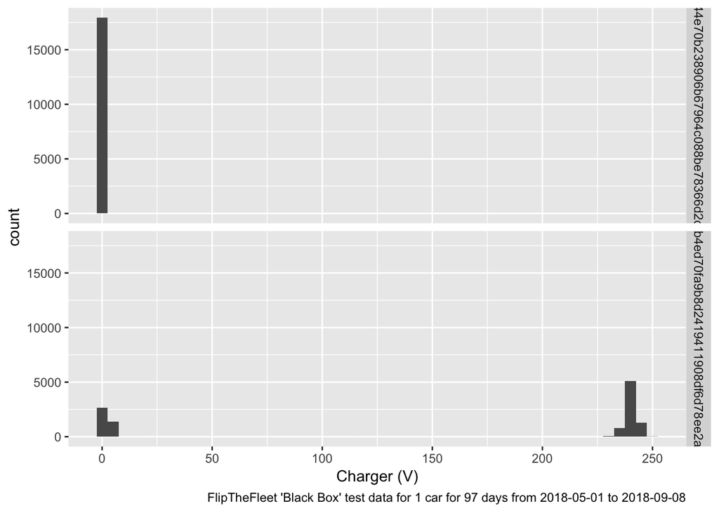

Figure 3.2: Distribution of charger volt readings

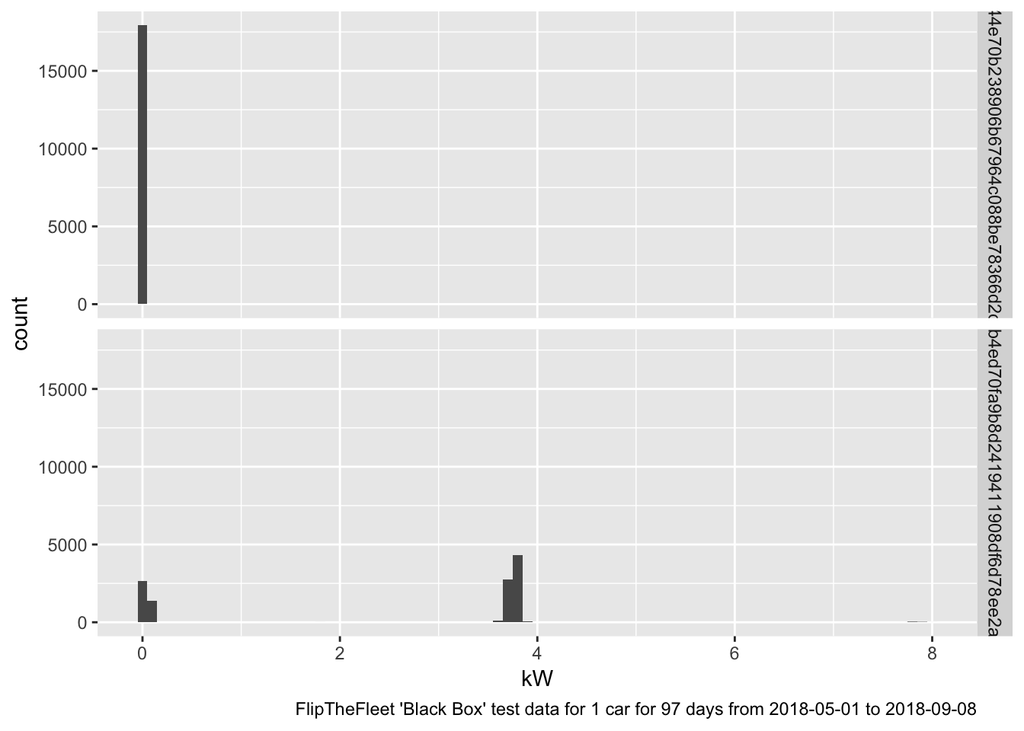

Figure 3.3: Distribution of derived power demand

The following table sumarises these distributions.

Table 3.1: Summary of Charger (amps)

Charger (amps)

Charger (V)

[output not shown]

Min. : 0.000

Min. : 0.000

Min. : 0.0

1st Qu.: 0.000

1st Qu.: 0.000

1st Qu.: 0.0

Median : 0.000

Median : 0.000

Median : 0.0

Mean : 4.663

Mean : 60.265

Mean : 947.4

3rd Qu.:15.562

3rd Qu.: 6.398

3rd Qu.: 103.2

Max. :33.438

Max. :249.445

Max. :7977.2

*XX Is the Amp reading of 33 an outlier? If so should we ignore the ~= 8kW values? XX*

# 4 Analaysis: Number of cars over time

Just a simple trend line…

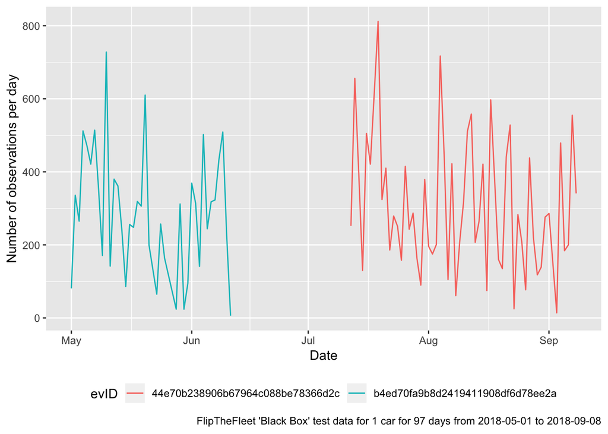

# 5 Analysis: Timing of charging

We assume `powerW` is a good indicator of charging. For now we do not exclude the apparent outlier caused by the few very high Amp values (`Charger (amps)` > 30) but we flag them as potential problems.

Figure 5.1 shows mean kW by time of day over the entire test datset of 97 days from 2018-05-01 to 2018-09-08.

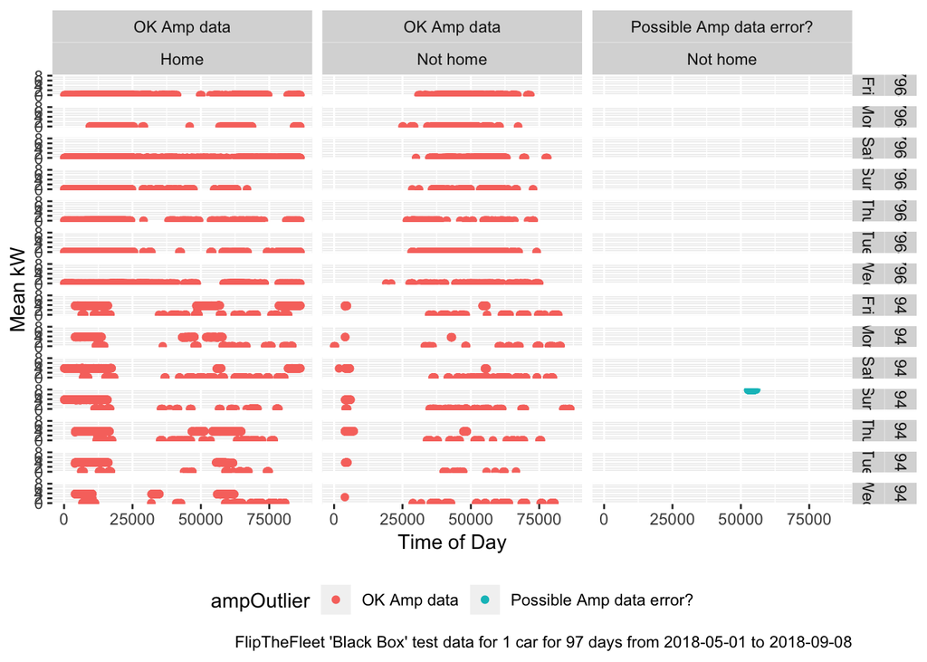

Figure 5.1: Inferred charging times and power draw (all data)

Figure 5.1 seems to show that the very high Amp values occured on one Sunday and we also appear to see some night charging ‘not at home’ which may indicate our location inference is imperfect. We re-draw this plot (Figure 5.2) excluding the Amp outliers and also excluding values of exactly 0 for clarity.

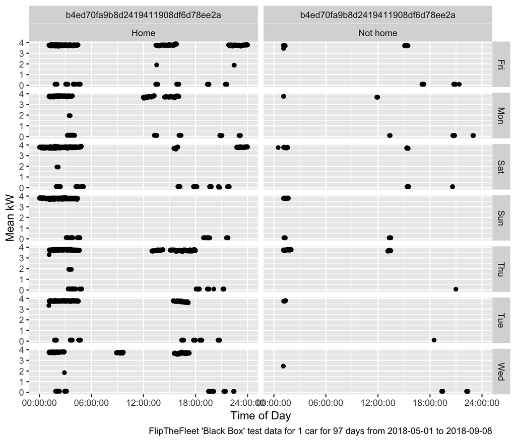

Figure 5.2: Inferred charging times and power draw (outliers and exactly zero values excluded)

We can see that this car appears to be on an overnight charging timer at home although we do still see charging scattered through the rest of the day.

So where is the non-home charging happening? We need a way to infer other locations without being disclosive.

# 6 Conclusions

Questions to be asked

- Data:
  - Do the Amp & Volt distributions look right?
  - Cause of Amp outliers?
  - Date/Time NA (37.38 % of observations) are due to a lack of GPS date/time (and lat/long). Does this mean that there is no date/time in the data when GPS has no signal? Our tests suggest that other data (e.g. power etc) is logged even though there is no date/time. Do we need another source of date/time? Could we infer time from seconds since powered on (assumes GPS OK at start-up?)?
- Research:
  - Do all FlipTheFleet EV owners charge like this?
  - Where are the EVs being charged when not at home and how can we tell?
  - Does it vary by car/tariff/commute pattern/main use?
  - What other patterns exist and how much within-vehicle and between-vehicle variation is there?

# 7 Runtime

Analysis completed in 13.82 seconds ( 0.23 minutes) using knitr in [RStudio](http://www.rstudio.com) with R version 3.5.1 (2018-07-02) running on x86_64-apple-darwin15.6.0.

# 8 R environment

R packages used:

# References

Dowle, M, A Srinivasan, T Short, S Lianoglou with contributions from R Saporta, and E Antonyan. 2015. *Data.table: Extension of Data.frame*. https://CRAN.R-project.org/package=data.table.

Grolemund, Garrett, and Hadley Wickham. 2011. “Dates and Times Made Easy with lubridate.” *Journal of Statistical Software* 40 (3): 1–25. http://www.jstatsoft.org/v40/i03/.

R Core Team. 2016. *R: A Language and Environment for Statistical Computing*. Vienna, Austria: R Foundation for Statistical Computing. https://www.R-project.org/.

Wickham, Hadley. 2009. *Ggplot2: Elegant Graphics for Data Analysis*. Springer-Verlag New York. http://ggplot2.org.

Wickham, Hadley, Jim Hester, and Romain Francois. 2016. *Readr: Read Tabular Data*. https://CRAN.R-project.org/package=readr.

Xie, Yihui. 2016. *Knitr: A General-Purpose Package for Dynamic Report Generation in R*. https://CRAN.R-project.org/package=knitr.